# Part-I Prepare Data Matrix

### 3.2.2 Feature importance from coefficients(基于系数的特征重要性)

为了计算这些feature的重要性，我首先使用了LassoCV来进行估计特征的coefficients。具有最高系数绝对值的特征被认为是最重要的。但在实际运行中，大多数特征的coef均为0，因此这一方法被废弃。

```python
import matplotlib.pyplot as plt
from sklearn.linear_model import MultiTaskLassoCV

lasso = MultiTaskLassoCV().fit(X_train, y_train_one_hot)
importance = np.abs(lasso.coef_)
print(len(importance))
feat_rank = np.argsort(-importance)
i = 0
feat_coef = []
while i < len(feat_rank[0]):
    if(feat_rank[0][i]<31):
        feat_coef.append(feature_names[i])
    i += 1
# print(feat_coef)
feat_coef = pd.DataFrame(feat_coef)
feat_coef.to_csv('result_coef.csv')
```

```
6
```

### 3.2.3 Selecting features based on importance(基于重要性选择特征)

在sfm中，考虑到结果中的一项冗余项，我将所要选取的特征数设定为31.

```python
from sklearn.ensemble import RandomForestClassifier
from sklearn.feature_selection import SelectFromModel
from time import time

tic = time()
clf = RandomForestClassifier(n_estimators=50)
clf.fit(X_train, y_train_one_hot)
sfm = SelectFromModel(clf,prefit=True,max_features=31)
toc = time()
feature_names = np.array(feature)
feat_sfm = pd.DataFrame(feature_names[sfm.get_support()])
feat_sfm.to_csv('result_sfm.csv')

print(feat_sfm.shape)
print("Features selected by SelectFromModel: "
      f"{feature_names[sfm.get_support()]}")
print(f"Done in {toc - tic:.3f}s")
```

```
(31, 1)
Features selected by SelectFromModel: ['ENSG00000052126.14.mRNA.PLEKHA5.ENSG00000052126.14.ENSG00000052126.14.0.12558'
 'ENSG00000068885.14.mRNA.IFT80.ENSG00000068885.14.ENSG00000068885.14.0.7175'
 'ENSG00000072042.12.mRNA.RDH11.ENSG00000072042.12.ENSG00000072042.12.0.5518'
 'ENSG00000085872.14.mRNA.CHERP.ENSG00000085872.14.ENSG00000085872.14.0.6113'
 'ENSG00000086666.18.mRNA.ZFAND6.ENSG00000086666.18.ENSG00000086666.18.0.5153'
 'ENSG00000099977.13.mRNA.DDT.ENSG00000099977.13.ENSG00000099977.13.0.1753'
 'ENSG00000102317.17.mRNA.RBM3.ENSG00000102317.17.ENSG00000102317.17.0.3731'
 'ENSG00000118855.18.mRNA.MFSD1.ENSG00000118855.18.ENSG00000118855.18.0.5288'
 'ENSG00000127314.17.mRNA.RAP1B.ENSG00000127314.17.ENSG00000127314.17.0.16942'
 'ENSG00000132670.20.mRNA.PTPRA.ENSG00000132670.20.ENSG00000132670.20.0.4469'
 'ENSG00000134851.12.mRNA.TMEM165.ENSG00000134851.12.ENSG00000134851.12.0.7045'
 'ENSG00000136731.12.mRNA.UGGT1.ENSG00000136731.12.ENSG00000136731.12.0.11349'
 'ENSG00000140941.12.mRNA.MAP1LC3B.ENSG00000140941.12.ENSG00000140941.12.0.5313'
 'ENSG00000143222.11.mRNA.UFC1.ENSG00000143222.11.ENSG00000143222.11.0.2274'
 'ENSG00000146066.2.mRNA.HIGD2A.ENSG00000146066.2.ENSG00000146066.2.0.668'
 'ENSG00000147123.10.mRNA.NDUFB11.ENSG00000147123.10.ENSG00000147123.10.0.1418'
 'ENSG00000157500.10.mRNA.APPL1.ENSG00000157500.10.ENSG00000157500.10.0.7033'
 'ENSG00000162441.11.mRNA.LZIC.ENSG00000162441.11.ENSG00000162441.11.0.2794'
 'ENSG00000163320.10.mRNA.CGGBP1.ENSG00000163320.10.ENSG00000163320.10.0.6490'
 'ENSG00000165283.15.mRNA.STOML2.ENSG00000165283.15.ENSG00000165283.15.0.1806'
 'ENSG00000176845.12.mRNA.METRNL.ENSG00000176845.12.ENSG00000176845.12.0.2626'
 'ENSG00000178904.18.mRNA.DPY19L3.ENSG00000178904.18.ENSG00000178904.18.0.10781'
 'ENSG00000181016.9.mRNA.LSMEM1.ENSG00000181016.9.ENSG00000181016.9.0.2592'
 'ENSG00000183690.12.mRNA.EFHC2.ENSG00000183690.12.ENSG00000183690.12.0.3319'
 'ENSG00000198589.10.mRNA.LRBA.ENSG00000198589.10.ENSG00000198589.10.0.14929'
 'ENSG00000256671.6.mRNA.LIMS4.ENSG00000256671.6.ENSG00000256671.6.0.2553'
 'ENSG00000257167.2.lncRNA.TMPO.AS1.ENSG00000257167.2.ENSG00000257167.2.0.3357'
 'ENSG00000259719.5.lncRNA.LINC02284.ENSG00000259719.5.ENSG00000259719.5.0.846'
 'ENSG00000259753.1.mRNA.AC068234.1.ENSG00000259753.1.ENSG00000259753.1.0.2785'
 'hsa_circ_0006790.circRNA.hsa_circ_0006790.hsa_circ_0006790.hsa_circ_0006790.0.450'
 'hsa_circ_0073222.circRNA.hsa_circ_0073222.hsa_circ_0073222.hsa_circ_0073222.0.440']
Done in 0.661s
```

## 3.3 Machine Learning

### 3.3.1 Model Construction

在这一部分中，首先编写了选取训练模型的函数，接着对各种特征选择方法的结果以及全特征进行模型训练。本例中使用了RandomForest模型。

```python
import pandas as pd
import numpy as np
import matplotlib.pyplot as plt
from sklearn.preprocessing import StandardScaler
from sklearn.model_selection import train_test_split
from sklearn.model_selection import StratifiedKFold
from sklearn.model_selection import GridSearchCV
from sklearn.model_selection import LeaveOneOut
from sklearn.tree import DecisionTreeClassifier
from sklearn.svm import LinearSVC, SVC
from sklearn.ensemble import RandomForestClassifier
from sklearn.linear_model import LogisticRegression
from sklearn.metrics import roc_curve,roc_auc_score,auc,precision_recall_curve,average_precision_score,accuracy_score

def clf_select(name):
    if name =='DT':
        clf = DecisionTreeClassifier(max_depth=5, min_samples_leaf=5, criterion='gini')
    elif name =='DT_cv':
        tree_para = {'max_depth': [3,5,7,9]}
        clf = GridSearchCV(DecisionTreeClassifier(), tree_para, cv=5)
    elif name == 'SVM':
        clf = SVC(kernel='rbf', probability=True, C=1)
    elif name == 'SVM_cv':
        tree_para = { 'C':[0.00001, 0.0001, 0.001, 0.01, 0.1, 1, 10, 100, 1000, 10000, 100000]}
        clf = GridSearchCV(SVC(kernel= 'rbf',probability=True), tree_para, cv=5)
    elif name == 'RF':
        clf = RandomForestClassifier(n_estimators=50, max_depth=5)
    elif name == 'RF_cv':
        tree_para = {'n_estimators': [25, 50, 75],'max_depth': [3, 4, 5]}
        clf = GridSearchCV(RandomForestClassifier(), tree_para, cv=5)
    elif name == 'LR_cv':
        tree_para = {'C': [0.00001, 0.0001, 0.001, 0.01, 0.1, 1, 10, 100, 1000, 10000, 100000]}
        clf = GridSearchCV(LogisticRegression(penalty='l2',solver='liblinear'), tree_para, cv=5)
    return clf


best_feature_rfe = pd.read_csv('rfe_feature.csv').iloc[2:,1]
best_feature_lime = pd.read_csv('sig_feature_trimmed.csv').iloc[1:,1].values
best_feature_all = X_train.columns
best_feature_sfm = pd.read_csv('result_sfm.csv').iloc[2:,1].values

def training(best_feature, method, model = 'RF_cv'):
    result_train = pd.DataFrame(columns={'feature', 'AUC_mean'})
    result_test = pd.DataFrame(columns={'feature', 'AUC_mean'})

    clf = clf_select(model)
    clf.fit(X_train.loc[:, best_feature], y_train)

    y_predict=clf.predict(X_test.loc[:, best_feature])
    proba=clf.predict_proba(X_test.loc[:, best_feature])
    fpr, tpr, thresholds = roc_curve(y_one_hot.ravel(),proba.ravel())
    roc_auc = auc(fpr, tpr)
    print(f"基于{method}选择特征的模型auc：{roc_auc}")
    return fpr, tpr, model, method, roc_auc

my_all = training(best_feature_all, method = 'all-feature')
my_sfm = training(best_feature_sfm, method = 'rf-based sfm')
my_rfe = training(best_feature_sfm, method = 'rfe')
my_lime = training(best_feature_lime, method = 'lime')
```

```
基于all-feature选择特征的模型auc：0.8682125473228773
基于rf-based sfm选择特征的模型auc：0.8479786371011359
基于rfe选择特征的模型auc：0.8179894537587885
基于lime选择特征的模型auc：0.8036235803136831
```

### 3.3.2 训练结果可视化

最后绘制训练结果的roc曲线，整体结果相对较好，模型auc均在0.8以上，但特征选择后的效果普遍低于全特征训练，可能与所选取的特征数不合适，产生了过拟合有关。后续的进一步检查可以通过与训练集准确率的比较，更改选取的特征数等方式进行。

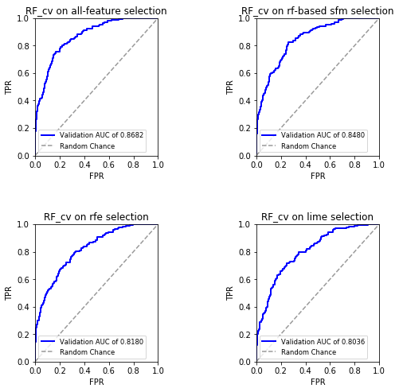

```python
def train2plot(train, loc):
    a = list(train)
    a.append(loc)
    return a

def plotCurve(plot):
    fpr, tpr, model, method, roc_auc, location = plot
    plt.subplot(2,2,location)
    plt.plot(fpr, tpr, '-', color='b', label='Validation AUC of {:.4f}'.format(roc_auc), lw=2)
    plt.plot([0, 1], [0, 1], '--', color=(0.6, 0.6, 0.6), label='Random Chance')
    plt.xlim([0, 1])
    plt.ylim([0, 1])
    plt.title(f'{model} on {method} selection')
    plt.xlabel('FPR')
    plt.ylabel('TPR')
    plt.legend(loc='best',fontsize='small')

all_plot = train2plot(my_all,1)
sfm_plot = train2plot(my_sfm,2)
rfe_plot = train2plot(my_rfe,3)
lime_plot = train2plot(my_lime,4)

plt.figure(figsize=(6,6))
# plt.suptitle('ROC curve of training results')
plotCurve(all_plot)
plotCurve(sfm_plot)
plotCurve(rfe_plot)
plotCurve(lime_plot)
plt.subplots_adjust(0,0,1,1,hspace=0.5,wspace=0.8)
plt.show()
plt.close()
```